# Panorama des techniques d’analyse textuelle

## Score aggrégé grossier

Pour illustrer, on utilise un dictionnaire associant un score à 2000 mots en fonction de leur connotation positive ou négative (Tom De Smedt).

```r
pos.words[1:10]
```

```
##  [1] "tout"  "petit" "grand" "seul"  "bon"   "beau"  "jeune" "noir"
##  [9] "vrai"  "sûr"
```

```r
neg.words[1:10]
```

```
##  [1] "vieux"    "long"     "blanc"    "gros"     "rouge"    "possible"
##  [7] "bleu"     "mauvais"  "heureux"  "pauvre"
```

Si on les applique aux réponses à la question ouverte portant sur la police, ça ne marche pas très bien, le dictionnaire n'est pas pertinent…

## Score aggrégé grossier

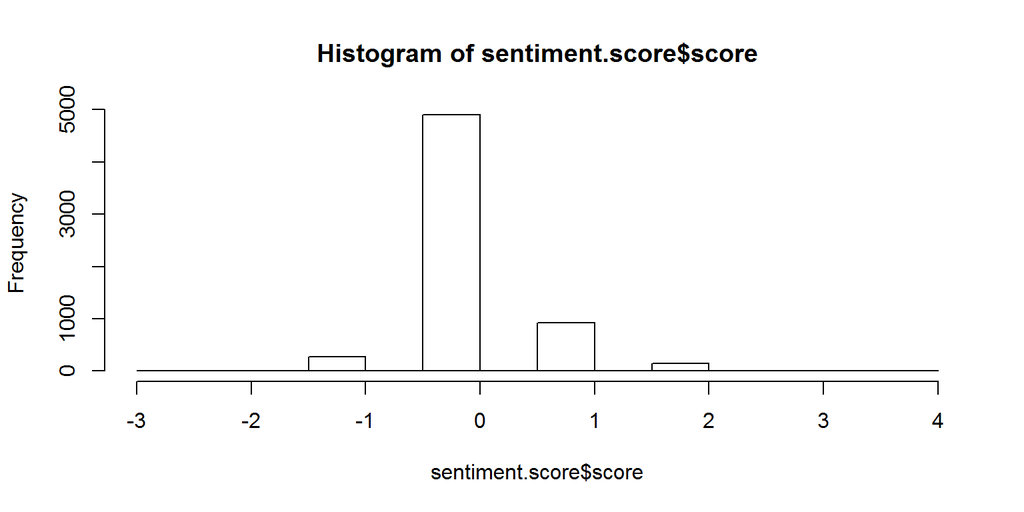

```r
sentiment.score <- score.sentiment(police,pos.words,neg.words)
hist(sentiment.score$score)
```

## Prise en compte du contexte

Une version plus élaborée peut être trouvée dans le package `qdap`, où l'on peut également paramétrer le dictionnaire des mots positifs ou négatifs, mais également prendre en compte le contexte (les négations ou termes amplifiant/minimisant le propos dans le contexte du mot polarisé). La limite étant qu'il faille disposer ou construire de tels dictionnaires (en première approche nous avons traduits les dictionnaires anglais).

```r
library(qdap)
ref <- sentiment_frame(pos.words, c(neg.words,negation.words))
c<-counts(polarity(police,negators = negation.words, amplifiers = amplification.words,
    deamplifiers = deamplifiers.words, question.weight = 0, n.before = 4,
    n.after = 2, polarity.frame=ref))
c[1:3,]
```

```
##   all wc polarity pos.words neg.words                                                                                            text.var
## 1 all 14    0.000         -         - trop de repressions de petites infractions il faudrait quils soccupent de problemes plus importants
## 2 all 14   -0.267         -       pas                  des choses sont punis severement d autres pas assez trop d inegalite de traitement
## 3 all 11    0.000         -         -                                                       a du mal a s adapter a la situation du moment
```

## Prise en compte du contexte

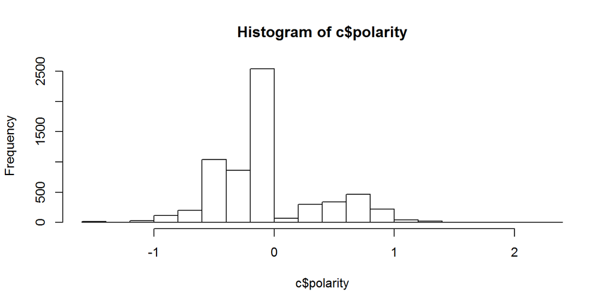

```r
hist(c$polarity)
```

## Ontologies

Il existe un certain nombre de dictionnaires en anglais pour les synonymes, les antonymes, les hypo ou hypernymes, des classifications (par exemple le mot "procès" sera dans la classe "juridique"), ou encore des qualifications en termes de sentiments.

L'un de ces dictionnaires est **Wordnet**, il existe des versions françaises, on peut voir si on peut récupérer dans **Wordnet** l'identifiant correspondant anglais pour trouver par exemple un synonyme.

Une autre solution, est de traduire les termes automatiquement, par exemple en utilisant une API telle que Yandex, mais le nombre de requête est limité par jour.

## Ontologies

```r
library(RCurl)
traduction<-function(mot){
api<-votre_cle_a_recuperer_sur_le_site
src.url<-URLencode(paste("https://translate.yandex.net/api/v1.5/tr/translate?key=",api,"&text=",mot,"&lang=en-fr",sep=""))
html.parse<-htmlTreeParse(getURL(src.url,.opts=opts),useInternalNodes=TRUE)
content<-getNodeSet(html.parse,'//text')
xmlSApply(content, xmlValue)}
mot<-"chaud"
traduction(mot)
#"hot"
```

## Ontologies

```r
library(wordnet)
initDict(pathData = "F:/analyse textuelle/wordnet-1.6/dict")
```

```
## [1] TRUE
```

```r
setDict("F:/analyse textuelle/wordnet-1.6/dict")
filter <- getTermFilter("ExactMatchFilter", "hot", TRUE)
terms <- getIndexTerms("ADJ", 1, filter)
synsets <- getSynsets(terms[[1]])
related <- getRelatedSynsets(synsets[[1]],"!")
sapply(related, getWord)
```

```
## [1] "cold"
```

## SentiWordnet

```r
letter<-function(pos){
if (pos=="adj"){"a"}
if (pos=="adv"){"r"}
if (pos=="verb"){"v"}
else{"n"}}
index<-function(mot,POS){
filter <- getTermFilter("ExactMatchFilter", mot, TRUE)
terms <- getIndexTerms(POS, 1, filter)
code <- terms[[1]]$toString()
pos <- terms[[1]]$getPartOfSpeech()
pos <- pos$toString()
m<-gregexpr("[0-9]{2,8}",code,perl=TRUE)
nb<-regmatches(code, m)[[1]][1]
paste(c(letter(pos),"-",rep("0",8-nchar(nb)),nb), collapse = "")}
id<-index("consternation","NOUN")
id
```

```
## [1] "n-05590744"
```

## SentiWordnet

```r
id<-"n-05590744"
arbre(id)
```

```
## [1] "n-05590744"
## [1] "alarm"
## [1] "negative-fear"
## [1] "negative-emotion"
## [1] "emotion"
## [1] "affective-state"
## [1] "mental-state"
## [1] "root"
```

## Word2Vec

Le modèle **Word2Vec** introduit par Mikolov en 2013 (Google), permet de représenter tous les mots du vocabulaire dans un espace de dimension \(d\), hyperparamètre du modèle. Il peut être vu comme une variante des matrices de pondération présentées précédemment.

L'idée est de prendre en compte le contexte du mot (les mots avant et après dans une certaine limite de mots). Pour un mot \(m\) et un contexte \(c\), on peut donc considérer la probabilité \(P(c|m)\).

L'idée est donc d'estimer les hyperparamètres \(\theta\) de sorte à maximiser :

\[\arg \max_{\theta} \prod_{m \in text} \left[\prod_{c \in C(m)} p(c|m;\theta)\right] \hspace{1cm} \text{Soit :} \ \arg \max_{\theta} \prod_{(m,c) \in D} p(c|m;\theta)\]

## Réseaux de neurones

On peut paramétriser le **skip-gram** modèle d'après la littérature sur les réseaux de neurones en utilisant la fonction de liaison **soft-max** : \[p(c|w;\theta)=\frac{e^{v_c v_m}}{\sum_{c' \in C} e^{v_{c'} v_m}}\] où \(v_c\) et \(v_m\) sont des représentations vectorielles de \(c\) et \(m\) dans \(R^d\), à estimer.

On doit donc maximiser la quantité suivante :

\[\sum_{(m,c) \in D}(log e^{v_c v_m} - log \sum_{c'} e^{v_{c'} v_m })\]

## Negative sampling

L'intuition de cette modélisation est de se dire que la solution de ce problème fournira une bonne représentation \(v_m\) pour tout mot \(m\) dans le sens où des mots similaires fourniront des vecteurs proches.

Le problème provient de ce que cette optimisation est très exigeante en temps de calcul, du fait de la somme qui intervient dans le calcul de \(p(c|m;\theta)\) et qui porte sur tous les contextes possibles \(c'\). Le **negative sampling** offre une solution à ce problème.

Si on note \(p(D=1|m,c)\) la probabilité que la paire \((m,c)\) provienne du corpus d'entrainement, on peut se contraindre à résoudre : \[\arg \max log \prod_{(m,c) \in D} p(D=1|m,c;\theta)\]

## Raisonnement par analogie

En prenant \(p(D=1|m,c;\theta)=\frac{1}{1+e^{-v_c v_w}}\), le problème présente une solution évidente si on prend \(\theta\) tel que \(p(D=1|m,c;\theta)=1\) pour toutes les paires \((m,c)\), soit \(v_c=v_w\), mais comme on ne veut pas que tous les vecteurs soient égaux on va faire en sorte que cette probabilité soit faible pour les couples non présents dans les données en générant un ensemble \(D'\) de paires aléatoires supposées incorrectes. Il s'agit maintenant de résoudre :

\[\arg \max \prod_{(m,c) \in D} p(D=1|m,c;\theta) \prod_{(m,c) \in D'} p(D=0|m,c;\theta)\]

Entraîné sur un très gros corpus, un tel modèle pourra fournir des résultats jamais observés auparavant en termes de représentation sous forme mathématique de raisonnements, mais on ne sait pas très bien pourquoi ça marche…

\[vec(France)-vec(Paris)+vec(Berlin)=vec(Germany)\]